# R Tutorial For Business Analytics

Derek Lukacsko & Jonathan Bourne

September 8, 2016

# Introduction

This introduction is to help students on the BUSICS msc at UCL gain a basic understanding of programming in [R](https://cran.r-project.org/). The course is designed to be taught in the loosest sense of the word. Students will read the text and perform the exercises whilst someone barely more competant than themselves walks around and tries to help them. At the end of the course, they will be given the answer sheet, which will probably be worse than the work they have done.

The course focuses on a suite of packages created by [Hadley Wickham](http://hadley.nz/) called the “[tidyverse](https://cran.r-project.org/web/packages/tidyverse/tidyverse.pdf)”, These packages are very widly used across the R community and have greatly helped reduced the difficulty of learning about R.

## Sources of help

1. Typing `?` followed by the function name e.g `?help` or `?sum`
2. Google
3. [stackoverflow](http://www.stackoverflow.com)
4. [Rstudio’s cheatsheets](https://www.rstudio.com/resources/cheatsheets/) (for this you’ll neeed the wrangling and ggplot ones)
5. [ggplot2 help website](http://docs.ggplot2.org/current/)

# Setup

Setting up the environment can be very helpful to do in one place this first code chunk can store all the packages you need in your analysis, load any custom functions that you have made through out the analysis and store the locations of any folders that you use for easy folder switching.

**TIP:** When using Rstudio

- Short cuts can be very helpful especially inserting a new chunk using `ctrl+alt+i`
- To run code highlight it and press `ctrl+Enter`
- To view a dataframe double click on it’s name in the “Environment” tab

```r
# Load packages
packages <- c("tidyverse", "openxlsx", "caret", "randomForest")

#This piece of code will check to see if the packages you want to load are installed if they aren't it will install them
new.packages <- packages[!(packages %in% installed.packages()[,"Package"])]
if(length(new.packages)) install.packages(new.packages)

invisible(sapply(packages, library, character.only = TRUE))

#save the starting directory as a variable
basewd <-getwd()
```

# First Steps

R contains many different data sets and additional data sets are usually installed with new packages. You can see what packages are installed on your machineby typing `data()` in the command line. packages can be loaded using the following methods

```r
data("airquality") #creates a promise
airquality %>% head #anything that calls the promises causes it to be evaluated
```

```
##   Ozone Solar.R Wind Temp Month Day
## 1    41     190  7.4   67     5   1
## 2    36     118  8.0   72     5   2
## 3    12     149 12.6   74     5   3
## 4    18     313 11.5   62     5   4
## 5    NA      NA 14.3   56     5   5
## 6    28      NA 14.9   66     5   6
```

```r
rm(airquality) #delete the dataframe

testdf <- airquality #loading can also be done like this
rm(testdf) #we don't need this variable cluttering up the workspace
```

Load the `mtcars` data frame and assign it to the variable `df`

1. With the data frame you have just loaded, use the functions,`class`, `dim`, `head`, `colnames`, `names`, `View`.
2. Load the datasets `VADeaths` and `discoveries` and use the same functions, what happens? why do you think it happens?

```
## [1] "data.frame"
```

```
## [1] 32 11
```

```
##  [1] "mpg"  "cyl"  "disp" "hp"   "drat" "wt"   "qsec" "vs"   "am"   "gear"
## [11] "carb"
```

```
##                    mpg cyl disp  hp drat    wt  qsec vs am gear carb
## Mazda RX4         21.0   6  160 110 3.90 2.620 16.46  0  1    4    4
## Mazda RX4 Wag     21.0   6  160 110 3.90 2.875 17.02  0  1    4    4
## Datsun 710        22.8   4  108  93 3.85 2.320 18.61  1  1    4    1
## Hornet 4 Drive    21.4   6  258 110 3.08 3.215 19.44  1  0    3    1
## Hornet Sportabout 18.7   8  360 175 3.15 3.440 17.02  0  0    3    2
## Valiant           18.1   6  225 105 2.76 3.460 20.22  1  0    3    1
```

# Classes

In R all the objects you work with have different classes these can be data frames, matrices, models, vectors etc. Different objects have different properties, meaning they react differently to the functions you try on them.

Given that data frames can hold multiple data types it is worth checking what class each column in a data frame is. This can be boring to check one at a time so using a `for` loop could be an option. However R also has a group of functions called the `apply` family, `sapply`, and `lapply` being the most commonly used. These functions move across every element of a dataframe/matrix/list and perform a function on it returning the result.

## Check the class of each variable

1. Use sapply to sum up each column of the dataframe `df`
2. Use `sapply` to find out the classes of each varible in `df` compare this to the classes found in the `iris` data set.
3. Do you think the results of the summming function is surprising?

## Change class

As was seen in the previous exercise some of the variables of df could do with changing class. Class can be changed by calling `as.` before the class you want to convert to e.g `as.data.frame` if possible R will then coerce the object into the new class, or return an error if it is not possible.

A matrix can only hold a single class of information for example, integers **or** characters but not both. A data frame can hold multiple data types as long as they are vectors, this makes data frames much more flexible they are the building block of working in R. A list can hold whatever you like including other lists.

1. Change the cyl, vs, and am variables to factors (Use `lapply` or `mutate_at` if you can work out how)
2. Change hp to an integer
3. Using sapply check the changes have taken place

**Tip:** For changes to variables in a dataframe or matrix use mutate (look at the wrangling cheatsheet).

```
##       mpg       cyl      disp        hp      drat        wt      qsec
## "numeric"  "factor" "numeric" "integer" "numeric" "numeric" "numeric"
##        vs        am      gear      carb
##  "factor"  "factor" "numeric" "numeric"
```

```
##       mpg       cyl      disp        hp      drat        wt      qsec
## "numeric"  "factor" "numeric" "integer" "numeric" "numeric" "numeric"
##        vs        am      gear      carb
##  "factor"  "factor" "numeric" "numeric"
```

# Exploring Data

Getting an idea of what is going on in your data frame is an important first step in working with data, we have already learn a bit about how the data works, now we are going to go a bit deeper.

1. Use rownames() and mutate() to make a new variable called “model” that has the names of the cars
2. Use the summary function to get a an overview of the dataset
3. Return the data frame with only th first 5 car models
4. Return the data frame with the top 5 most fuel efficient cars
5. Return a dataframe with the 5 least fuel efficient cars
6. Find the most fuel efficient car for each cylinder group

| cyl | mpg | disp | hp | drat | wt | qsec | vs | am | gear | carb | model |
| --- | --- | --- | --- | --- | --- | --- | --- | --- | --- | --- | --- |
| 4 | 33.9 | 71.1 | 65 | 4.22 | 1.835 | 19.90 | 1 | 1 | 4 | 1 | 20 |
| 6 | 21.4 | 258.0 | 110 | 3.08 | 3.215 | 19.44 | 1 | 0 | 3 | 1 | 4 |
| 8 | 19.2 | 400.0 | 175 | 3.08 | 3.845 | 17.05 | 0 | 0 | 3 | 2 | 25 |

# Outside the R environment

Obviously installing packages requires exiting the R environment and accessing the packages online at CRAN, however other times it is usefull to access things outside your R environment. In this section we will look at the basics of creating new folders, changing the working directory and saving files.

## Creating sub directories

In order to make our project manageable and easy to navigate we will create a new folder for the data.

1. Set the working directory to `basewd` which was defined at the begnining, you will need the function `setwd`.
2. Use the function `dir.create` to make a new folder called “R_tutorial”,check that it exists.
3. Change the working directory to be inside the “R_tutorial” folder, you might want to use the `file.path` function.
4. Create a folder called `Data` and set the working directory inside it.
5. Save the file path to the Data directory as a variable call it “DataFolder”

## Saving data

We have made some changes to our dataframe and so it is a good idea to save it somewhere. Getting data in and out of R that is not a preloaded dataset can be difficult when starting out so we will go through a few methods. The most common methods for saving data is `save`, `saveRDS`, `write.csv` which is a special case of `write.table`, and `write.xlsx` from the `opsenxlsx` package.

**Tip:** Remember to use the correct file extension at the end of the file name when saving, it makes it easier to identify files and for them to be opened by others.

1. Save a version of df using `write.csv` (dfcsv), `saveRDS` (dfRDS), and `write.xlsx` (dfxlsx)
2. Load the files using `read.csv`, `readRDS` and `read.xlsx`
3. Using the `all.equal` function compare the loaded files to the orignial df frame, what do you notice? you can also include `sapply` to compare each of the columns of the two dataframes.
4. delete all the dfxxx dataframes from the workspace.

**Note:** You may get an error message reffering to “Rtools” when you try to use `read.xlsx`, If you do just skip the xlsx bit and install Rtools later

**TIP:** You may wish to experiment including `row.names=1` when loading the csv.

The way you save files and the methods you can use to load data into your machine, affect what happens to it later. Generally saving data in RDS format is a good idea, it get compressed, and all class information is maintained, it can also be used to store other objects that are not tabular datasets, such as lists, models, etc. However you will seldom be lucky enough to recieve data in RDS format so knowing what to expect when that happens is important. Lookup the `readr` package and familiarise yourself with `stringsAsFactors` in `read.csv` that can ruin your day.

# Creating Plots

In this section we willl explore using ggplot2 R’s most popular plotting package to visualise data sets. We will begin using a simple scatter plot, and then build on it’s complexity by adding “layers”. After the scatter plot we will create a box plot which is very useful for representing catagorical/factoral data.

**Tip:** The ggplot cheat sheet will be pretty useful

## Scatterplot

1. Load the “iris” data set
2. Plot the relationship between variables Sepal.Length and Sepal.Width
3. add a linear regression
4. Color the points by Species
5. Bring fire

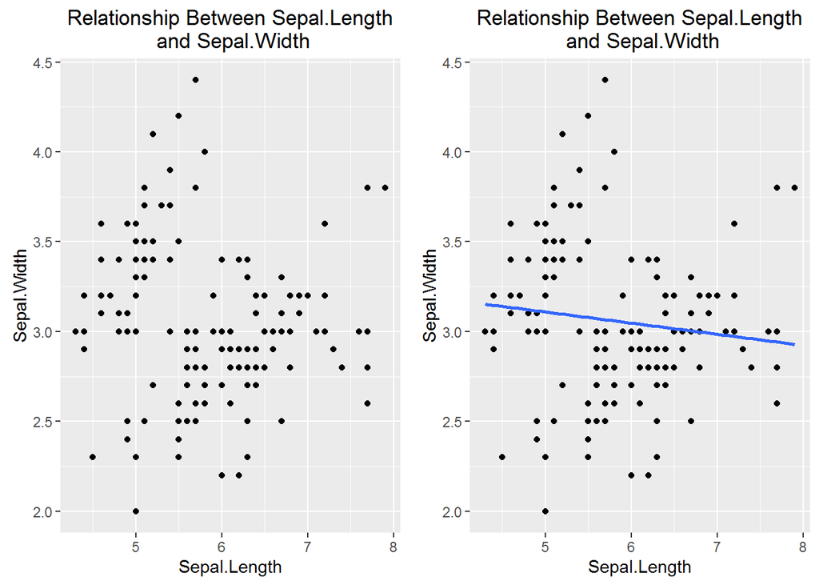

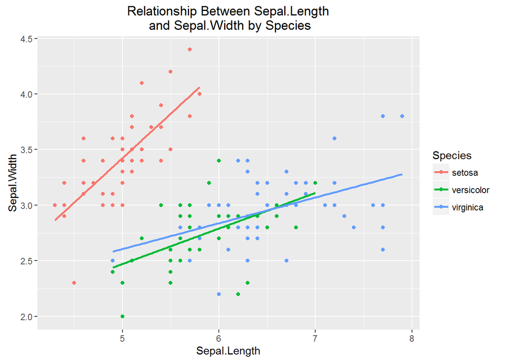

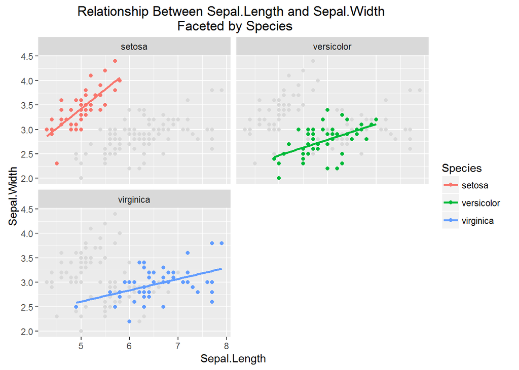

# Boxplots

Boxplots are a compact way of representing key statistics in categorical/factoral data. Often barplots are used to represent factoral data however they contain less information than barplots and so should generally be avoided.

1. Load “dfRDS.rds” and assign it to variable `df`
2. Make a barplot of mean mpg per cylinder, you will need to use `group_by` and `summarise`, also barplots need `stat=“identity” in the geom.
3. Make a box plot of mpg per cylinder
4. Make a new folder called “Figures” in “R_tutorial” use `ggsave` and create a pdf and a png of the boxplot
5. make a denisty plot using this data, how can this be useful?

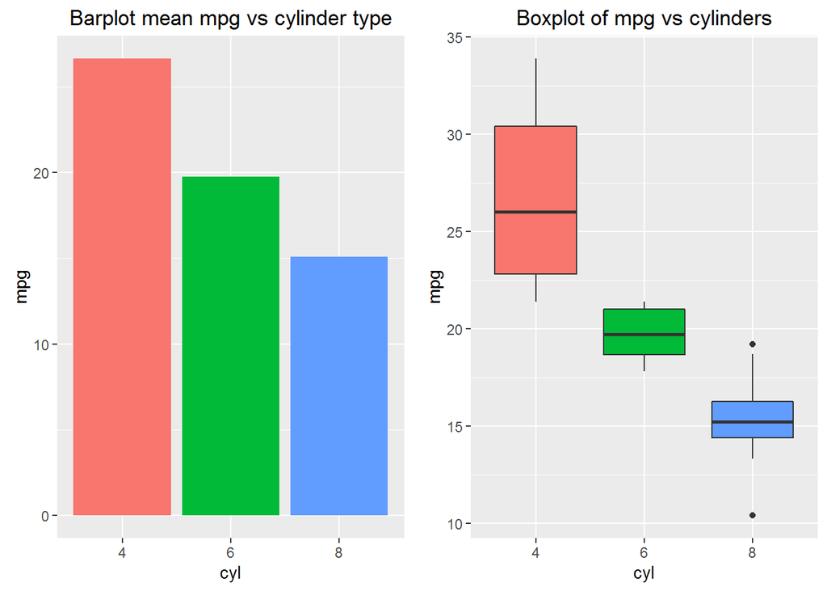

When you are making plots, barplots should only be used if you are using raw counts across categorical values, if you are using mean or any other statistic you are better off using a boxplot. Boxplots contain much more information about data than barplots. If you want to know how to put error bars on a bar plot you’re doing it wrong, use a box plot. If you are planning on making a 3D pie chart, do a different degree.

# Tidying Data

The tidyverse uses a concept called [tidy data](http://vita.had.co.nz/papers/tidy-data.pdf). Ggplot uses data in the long form of a tidy data set. in order to get data into this form the `gather` function is needed. Gather can be a bit tricky to work out so it’s worth spending a bit of time understanding it.

1. Assign the “WorldPhones” dataset to the “df” variable
2. Convert df from a matrix to a dataframe (Packages in the tidyverse only work with dataframes) and turn the row names in to a variable called year
3. Gather the data so that it comes into long form
4. Create a line plot coloured by continent
5. Add a title and rename the x and y axis to something more descriptive

**Tip:** Remember to exclude the Year variable from the gather command.

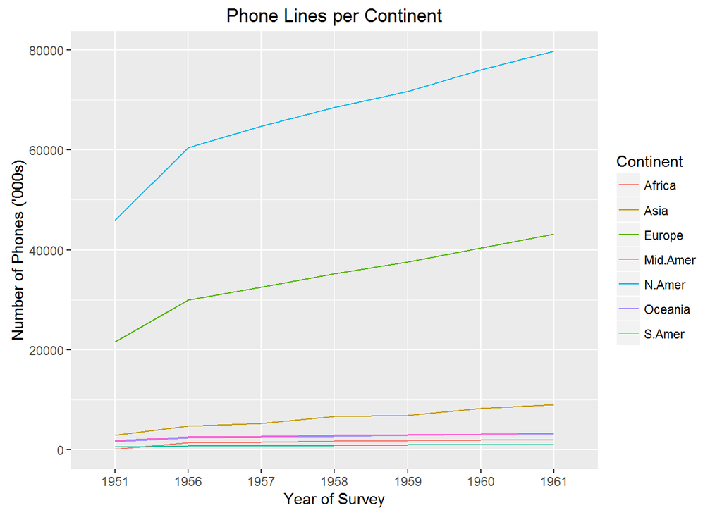

# Modelling

The bit that everyone body wants to get to in statistical programming is modelling. This part of the tutorial isn’t supposed to teach you about various machine learning techniques but how to apply them in R. Having said that we will cover the two main branches of machine learning Supervised and Unsupervised

# Supervised learning

Supervised learning is broadly speaking machine learning when you know the outcome you are trying to predict. This could be the results of sports events, age of death, rate of growth, anythign with a measurable (directly or indirectly) result.

## Regression

Regression predicts a continuous variable for amount earned by a company next quarter. The simplest form of regression that is generally considered is multi-linear regression $(X'X)^{-1}X'y = \beta$, the big sister of the “plot x against y and draw a line through the dots” everyone learnt about in school.

1. Load the “iris” dataset
2. Set the random seed to make sure the script is reproducible
3. Use `CreateDataPartition` to create a training set, where the input vector is “Species” and “list=FALSE”"
4. Create a linear model predicting “Sepal.Length”
5. Use `predict` and `postResample` to find the accuracy of the model on the test set.
6. Repeat the above with “method=rf” what do you notice?

```
##      RMSE  Rsquared
## 0.2565130 0.9146365
```

```
##      RMSE  Rsquared
## 0.3044859 0.8720734
```

## Classification

When the dependent variable is in distinct categories, classification is used. Classic examples of this include SPAM vs HAM and Cat vs Dog. The previous examples are binary outcomes, however there can also be multiclass classification which is more fiddly mathmatically but makes very little difference when implementing in R.

1. Use the random forest technique to predict species from the iris data set using all other variables
2. Using the predictions look at the results of `PostResample`
3. Compare the results with `confusionMatrix` what does it mean?
4. Extract just the confusion matrix from the `confusionMatrix`

```
## Accuracy    Kappa
##        1        1
```

```
## Confusion Matrix and Statistics
##
##             Reference
## Prediction   setosa versicolor virginica
##   setosa         10          0         0
##   versicolor      0         10         0
##   virginica       0          0        10
##
## Overall Statistics
##
##                Accuracy : 1
##                  95% CI : (0.8843, 1)
##     No Information Rate : 0.3333
##     P-Value [Acc > NIR] : 4.857e-15
##
##                   Kappa : 1
##  Mcnemar's Test P-Value : NA
##
## Statistics by Class:
##
##                      Class: setosa Class: versicolor Class: virginica
## Sensitivity                 1.0000            1.0000           1.0000
## Specificity                 1.0000            1.0000           1.0000
## Pos Pred Value              1.0000            1.0000           1.0000
## Neg Pred Value              1.0000            1.0000           1.0000
## Prevalence                  0.3333            0.3333           0.3333
## Detection Rate              0.3333            0.3333           0.3333
## Detection Prevalence        0.3333            0.3333           0.3333
## Balanced Accuracy           1.0000            1.0000           1.0000
```

```
## Accuracy    Kappa
##      0.6      0.2
```

```
## Confusion Matrix and Statistics
##
##           Reference
## Prediction A B
##          A 2 1
##          B 3 4
##
##                Accuracy : 0.6
##                  95% CI : (0.2624, 0.8784)
##     No Information Rate : 0.5
##     P-Value [Acc > NIR] : 0.3770
##
##                   Kappa : 0.2
##  Mcnemar's Test P-Value : 0.6171
##
##             Sensitivity : 0.4000
##             Specificity : 0.8000
##          Pos Pred Value : 0.6667
##          Neg Pred Value : 0.5714
##              Prevalence : 0.5000
##          Detection Rate : 0.2000
##    Detection Prevalence : 0.3000
##       Balanced Accuracy : 0.6000
##
##        'Positive' Class : A
##
```

```
## Accuracy    Kappa
##      0.6      0.2
```

```
## Confusion Matrix and Statistics
##
##           Reference
## Prediction A B
##          A 4 3
##          B 1 2
##
##                Accuracy : 0.6
##                  95% CI : (0.2624, 0.8784)
##     No Information Rate : 0.5
##     P-Value [Acc > NIR] : 0.3770
##
##                   Kappa : 0.2
##  Mcnemar's Test P-Value : 0.6171
##
##             Sensitivity : 0.8000
##             Specificity : 0.4000
##          Pos Pred Value : 0.5714
##          Neg Pred Value : 0.6667
##              Prevalence : 0.5000
##          Detection Rate : 0.4000
##    Detection Prevalence : 0.7000
##       Balanced Accuracy : 0.6000
##
##        'Positive' Class : A
##
```